# Quality of Red Wine

## Haakon Troemborg

### 15th of October 2015

========================================================

```
## 'data.frame':    1599 obs. of  13 variables:
##  $ X                   : int  1 2 3 4 5 6 7 8 9 10 ...
##  $ fixed.acidity       : num  7.4 7.8 7.8 11.2 7.4 7.4 7.9 7.3 7.8 7.5 ...
##  $ volatile.acidity    : num  0.7 0.88 0.76 0.28 0.7 0.66 0.6 0.65 0.58 0.5 ...
##  $ citric.acid         : num  0 0 0.04 0.56 0 0 0.06 0 0.02 0.36 ...
##  $ residual.sugar      : num  1.9 2.6 2.3 1.9 1.9 1.8 1.6 1.2 2 6.1 ...
##  $ chlorides           : num  0.076 0.098 0.092 0.075 0.076 0.075 0.069 0.065 0.073 0.071 ...
##  $ free.sulfur.dioxide : num  11 25 15 17 11 13 15 15 9 17 ...
##  $ total.sulfur.dioxide: num  34 67 54 60 34 40 59 21 18 102 ...
##  $ density             : num  0.998 0.997 0.997 0.998 0.998 ...
##  $ pH                  : num  3.51 3.2 3.26 3.16 3.51 3.51 3.3 3.39 3.36 3.35 ...
##  $ sulphates           : num  0.56 0.68 0.65 0.58 0.56 0.56 0.46 0.47 0.57 0.8 ...
##  $ alcohol             : num  9.4 9.8 9.8 9.8 9.4 9.4 9.4 10 9.5 10.5 ...
##  $ quality             : int  5 5 5 6 5 5 5 7 7 5 ...
```

```
##        X          fixed.acidity   volatile.acidity  citric.acid
##  Min.   :   1.0   Min.   : 4.60   Min.   :0.1200   Min.   :0.000
##  1st Qu.: 400.5   1st Qu.: 7.10   1st Qu.:0.3900   1st Qu.:0.090
##  Median : 800.0   Median : 7.90   Median :0.5200   Median :0.260
##  Mean   : 800.0   Mean   : 8.32   Mean   :0.5278   Mean   :0.271
##  3rd Qu.:1199.5   3rd Qu.: 9.20   3rd Qu.:0.6400   3rd Qu.:0.420
##  Max.   :1599.0   Max.   :15.90   Max.   :1.5800   Max.   :1.000
##  residual.sugar     chlorides       free.sulfur.dioxide
##  Min.   : 0.900   Min.   :0.01200   Min.   : 1.00
##  1st Qu.: 1.900   1st Qu.:0.07000   1st Qu.: 7.00
##  Median : 2.200   Median :0.07900   Median :14.00
##  Mean   : 2.539   Mean   :0.08747   Mean   :15.87
##  3rd Qu.: 2.600   3rd Qu.:0.09000   3rd Qu.:21.00
##  Max.   :15.500   Max.   :0.61100   Max.   :72.00
##  total.sulfur.dioxide    density             pH          sulphates
##  Min.   :  6.00       Min.   :0.9901   Min.   :2.740   Min.   :0.3300
##  1st Qu.: 22.00       1st Qu.:0.9956   1st Qu.:3.210   1st Qu.:0.5500
##  Median : 38.00       Median :0.9968   Median :3.310   Median :0.6200
##  Mean   : 46.47       Mean   :0.9967   Mean   :3.311   Mean   :0.6581
##  3rd Qu.: 62.00       3rd Qu.:0.9978   3rd Qu.:3.400   3rd Qu.:0.7300
##  Max.   :289.00       Max.   :1.0037   Max.   :4.010   Max.   :2.0000
##     alcohol         quality
##  Min.   : 8.40   Min.   :3.000
##  1st Qu.: 9.50   1st Qu.:5.000
##  Median :10.20   Median :6.000
##  Mean   :10.42   Mean   :5.636
##  3rd Qu.:11.10   3rd Qu.:6.000
##  Max.   :14.90   Max.   :8.000
```

Even though the quality is on a scale from 0 to 10, the wines are mostly either 5 or 6, and minimum 3 and maximum 8. This might have something to do with the fact that wine tasting is somewhat subjective, and the score is the median of several wine experts. All the data in the set is numeric.

# Univariate Plots Section

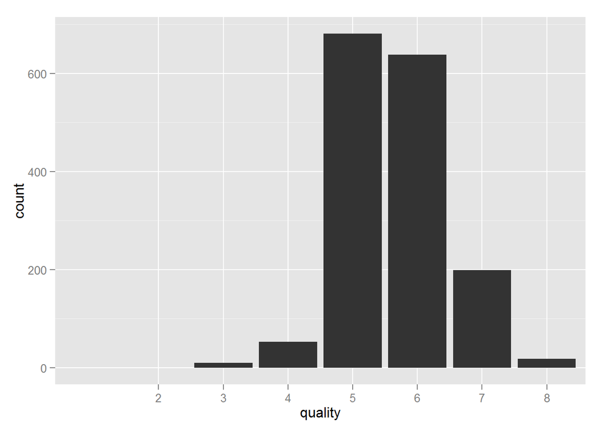

The quality seems to be approximately normally distributed around 5.5. Interestingly, it doesn’t utilize the full scale of 0 to 10. It’s gonna be interesting to see how this plays out compared to diamonds, where the price was more of a continuous nature.

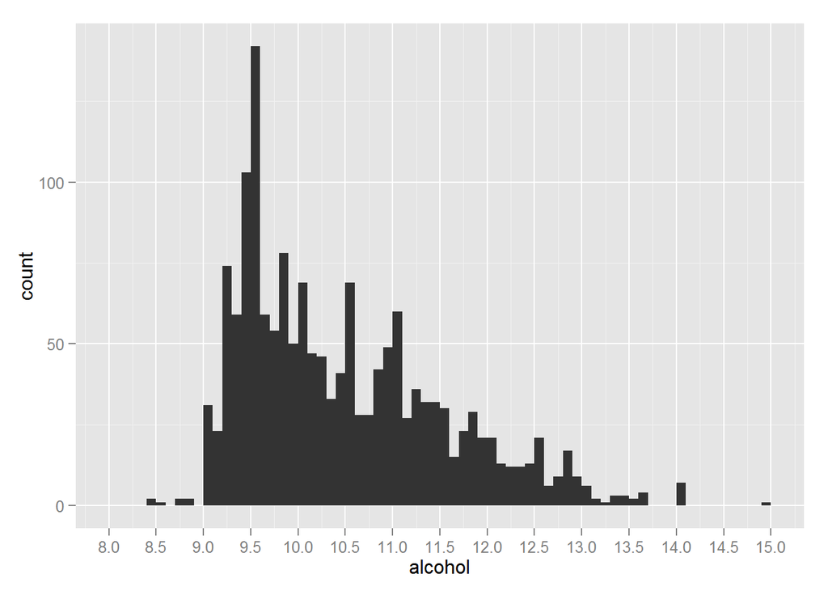

Alcohol seems to have more of a skewed distribution, where most of the wines are somewhere in the range of 9 to 12%. Alcohol percentage is something that many people claim to be able to taste, it’s gonna be interesting to see how this influences the quality.

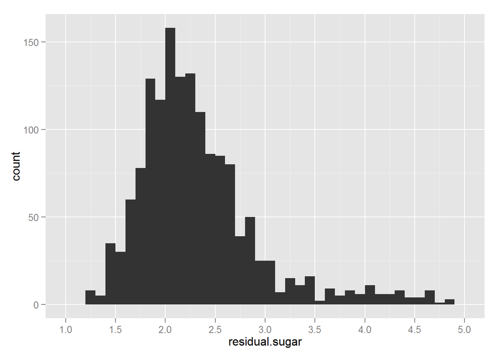

```
##  residual.sugar
##  Min.   : 0.900
##  1st Qu.: 1.900
##  Median : 2.200
##  Mean   : 2.539
##  3rd Qu.: 2.600
##  Max.   :15.500
```

Almost all of the sugar levels are in the range 1 to 3, but the other values can sometimes be much higher. I’ll have a look at these outliers in particular later on, to see if the they show some pattern in quality.

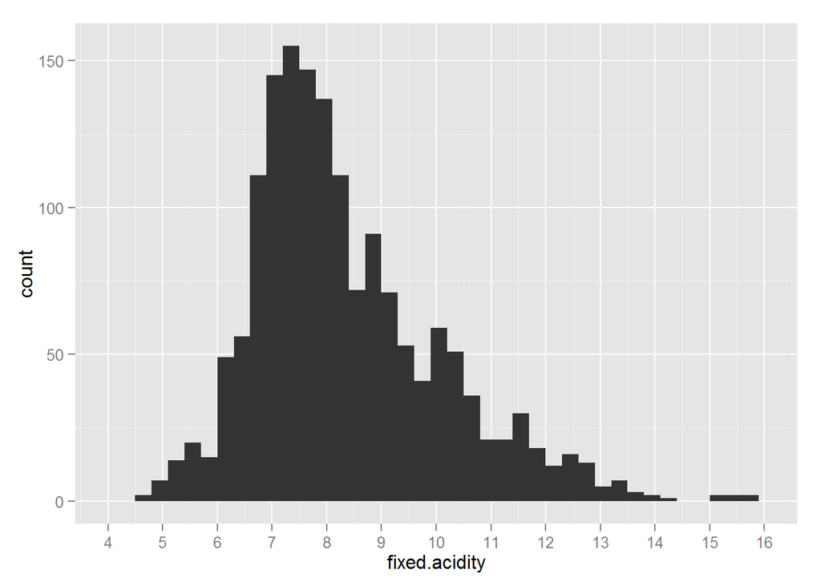

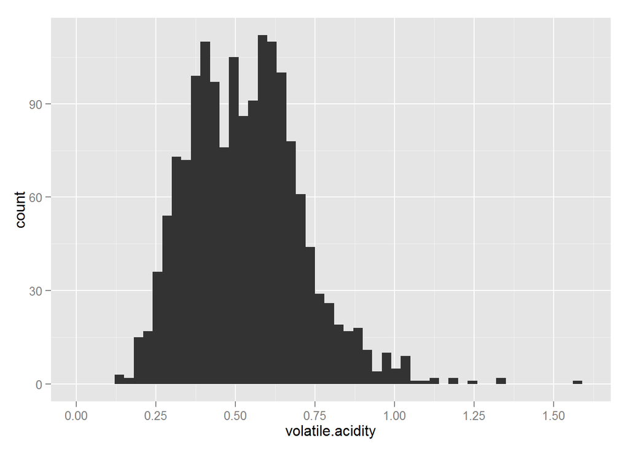

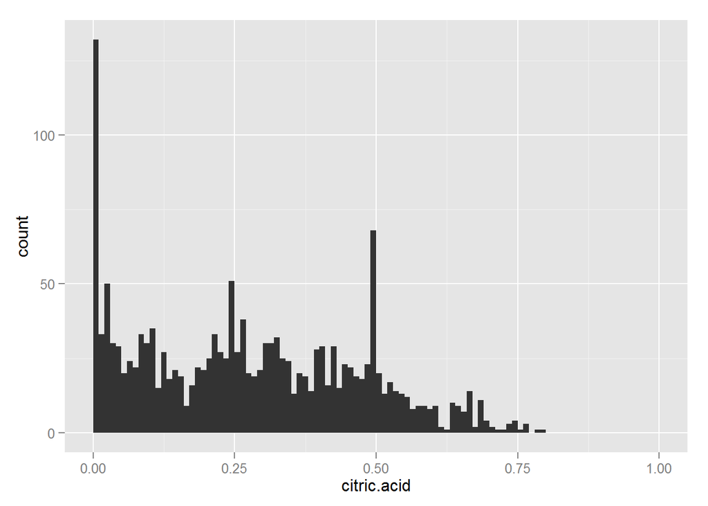

It’s hard to believe that the wine tasters are able to taste the difference between three acids, and so I’ll look into correlations between the three, and also how they relate to quality on their own and in common. Acids can obviously correlate with other qualities in wine though, so I’m not sure what to expect. Citric acid has two spikes, at 0 and 0.5. I speculate that thisis due to rounding error at 0.5, and the fact that some wines might contain almost no citric acid.

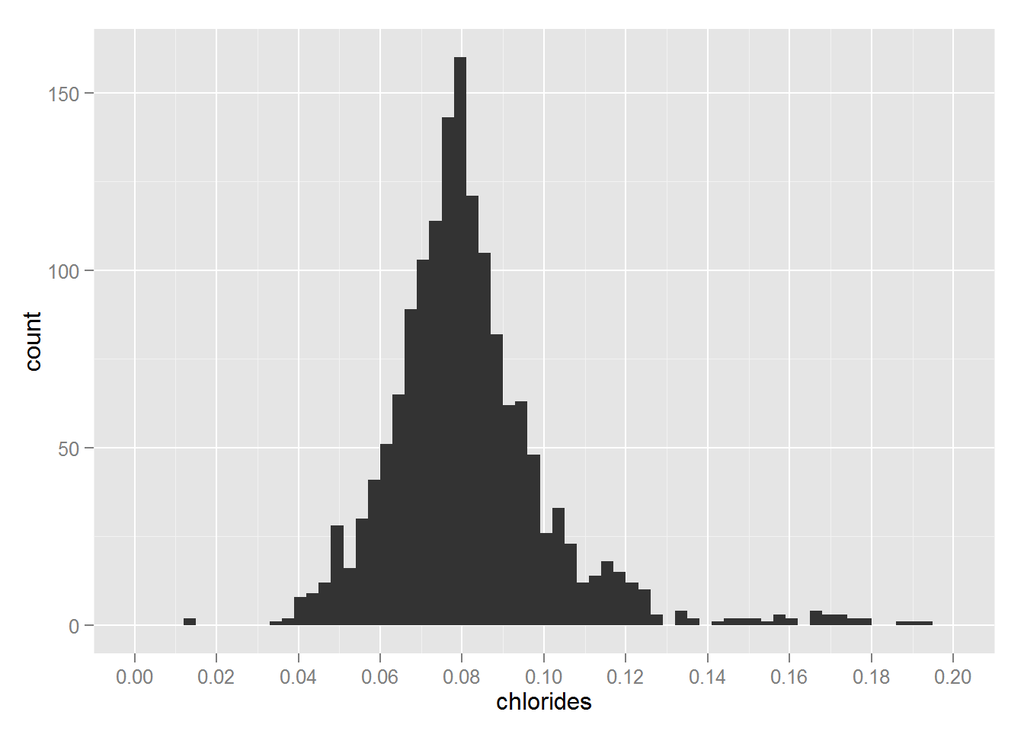

Chloride distribution looks pretty neat and normal, and saltiness is something I believe humans can taste pretty well. Beginning to notice a trend in histograms where the outliers are mostly on the higher end.

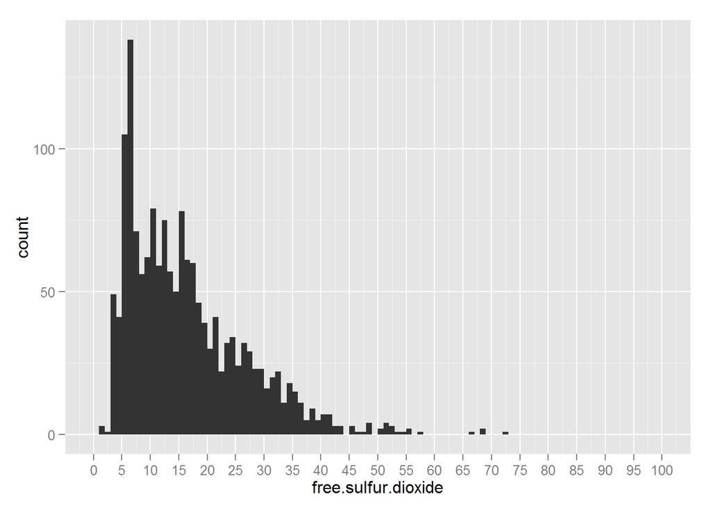

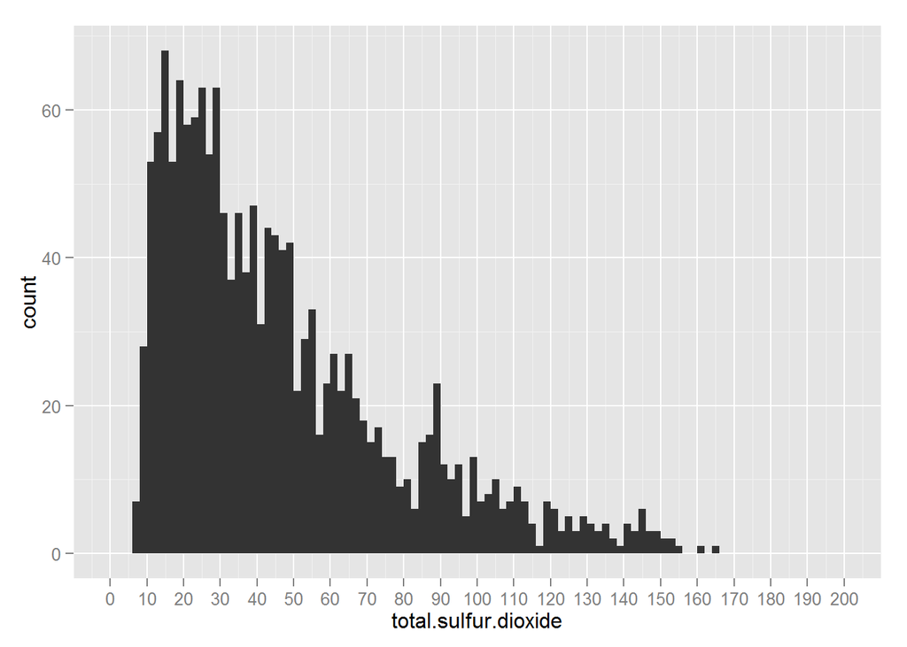

The distribution of the ammount of sulfur dioxide in the wine is very heavy tailed on the left side, so let’s have a look at its log transform.

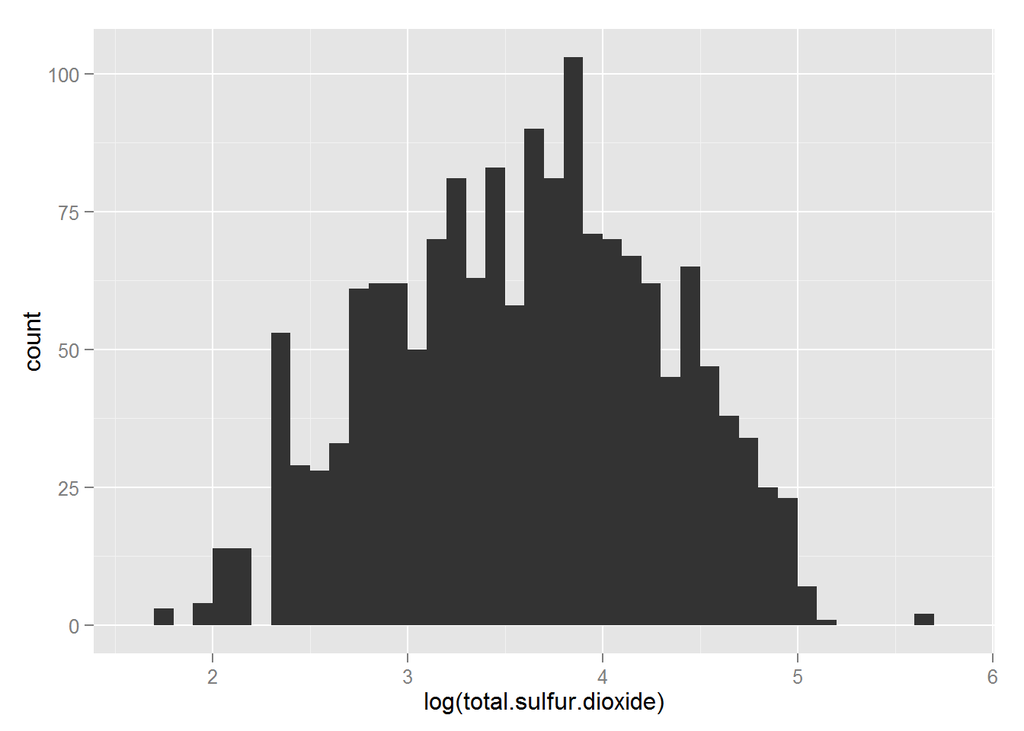

Seems to be more normal now. Once again, I believe these two will be related just like the acids. Total sulfur dioxide of course contains all the free dioxide, and we’ll see how they differ later on.

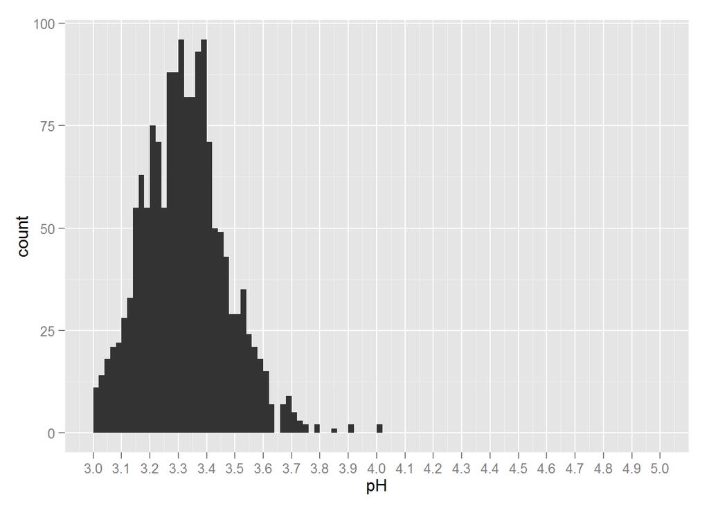

Sourness, like sweetness and saltiness, should be something that influences the taste of the win. I expect this to be a significant factor towards quality.

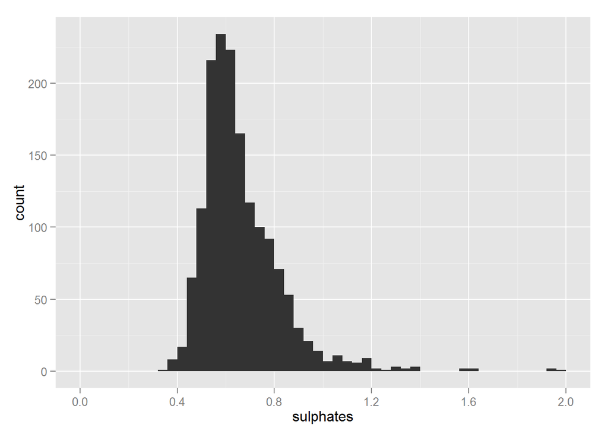

I remember from chemistry that sulfates typically taste and smell very strongly. The amount seems fairly normally distributed, so it’ll be interesting to have a look at the correlation as well as the outliers here.

# Univariate Analysis

### What is the structure of your dataset?

There are 1599 observations of 13 variables. Almost all are different measurements of chemical components in red wine, given as different weights per volume, or percentage of total volume. These are in principal continuous, but behave discretely with a relateively high resolution because of rounding and measurement accuracy. Quality stands out, which is given in integers from 3 to 8.

### What is/are the main feature(s) of interest in your dataset?

The main feature is quality, which is a mean of several expert wine tasters’ opinions of the different wines. The other features are equal, what will decide interest here is whether they show particular correlations with quality.

### What other features in the dataset do you think will help support your investigation into your feature(s) of interest?

As stated previously, I’m not looking to decide which features are “most interesting” yet. If I were to make a guess, I’d say chlorine, sugar, alcohol, sulphate and citric acid are the most distinguishable tastes though.

### Did you create any new variables from existing variables in the dataset?

No.

### Of the features you investigated, were there any unusual distributions? Did you perform any operations on the data to tidy, adjust, or change the form of the data? If so, why did you do this?

The distributions are in general either approximately normal, or long-tailed distributions, with outliers on the upper side. I didn’t perform any operations on the data.

# Bivariate Plots Section

```
##                          X fixed.acidity volatile.acidity citric.acid
## X                     1.00         -0.27            -0.01       -0.15
## fixed.acidity        -0.27          1.00            -0.26        0.67
## volatile.acidity     -0.01         -0.26             1.00       -0.55
## citric.acid          -0.15          0.67            -0.55        1.00
## residual.sugar       -0.03          0.11             0.00        0.14
## chlorides            -0.12          0.09             0.06        0.20
## free.sulfur.dioxide   0.09         -0.15            -0.01       -0.06
## total.sulfur.dioxide -0.12         -0.11             0.08        0.04
## density              -0.37          0.67             0.02        0.36
## pH                    0.14         -0.68             0.23       -0.54
## sulphates            -0.13          0.18            -0.26        0.31
## alcohol               0.25         -0.06            -0.20        0.11
## quality               0.07          0.12            -0.39        0.23
##                      residual.sugar chlorides free.sulfur.dioxide
## X                             -0.03     -0.12                0.09
## fixed.acidity                  0.11      0.09               -0.15
## volatile.acidity               0.00      0.06               -0.01
## citric.acid                    0.14      0.20               -0.06
## residual.sugar                 1.00      0.06                0.19
## chlorides                      0.06      1.00                0.01
## free.sulfur.dioxide            0.19      0.01                1.00
## total.sulfur.dioxide           0.20      0.05                0.67
## density                        0.36      0.20               -0.02
## pH                            -0.09     -0.27                0.07
## sulphates                      0.01      0.37                0.05
## alcohol                        0.04     -0.22               -0.07
## quality                        0.01     -0.13               -0.05
##                      total.sulfur.dioxide density    pH sulphates alcohol
## X                                   -0.12   -0.37  0.14     -0.13    0.25
## fixed.acidity                       -0.11    0.67 -0.68      0.18   -0.06
## volatile.acidity                     0.08    0.02  0.23     -0.26   -0.20
## citric.acid                          0.04    0.36 -0.54      0.31    0.11
## residual.sugar                       0.20    0.36 -0.09      0.01    0.04
## chlorides                            0.05    0.20 -0.27      0.37   -0.22
## free.sulfur.dioxide                  0.67   -0.02  0.07      0.05   -0.07
## total.sulfur.dioxide                 1.00    0.07 -0.07      0.04   -0.21
## density                              0.07    1.00 -0.34      0.15   -0.50
## pH                                  -0.07   -0.34  1.00     -0.20    0.21
## sulphates                            0.04    0.15 -0.20      1.00    0.09
## alcohol                             -0.21   -0.50  0.21      0.09    1.00
## quality                             -0.19   -0.17 -0.06      0.25    0.48
##                      quality
## X                       0.07
## fixed.acidity           0.12
## volatile.acidity       -0.39
## citric.acid             0.23
## residual.sugar          0.01
## chlorides              -0.13
## free.sulfur.dioxide    -0.05
## total.sulfur.dioxide   -0.19
## density                -0.17
## pH                     -0.06
## sulphates               0.25
## alcohol                 0.48
## quality                 1.00
```

We see that some of the values correlate pretty strongly, like citric and Volatile acidity, or fixed acidity and density. Let’s have a look at the ones that correlate most with quality.

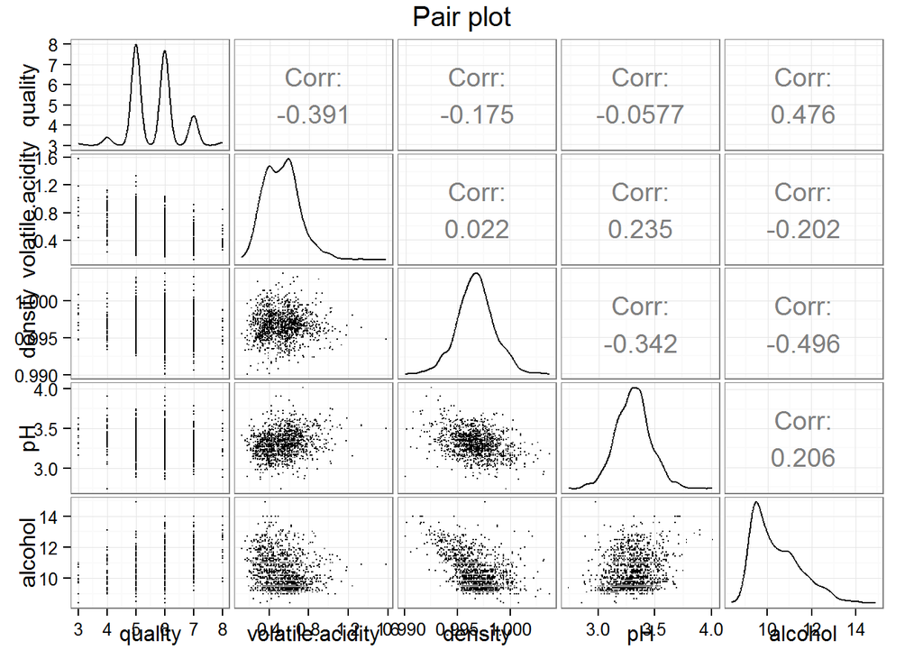

This plot gives a lot of information, and I’ll explore some of it further instead of discussing it all at once, let’s have a closer look at some of the scatter plots.

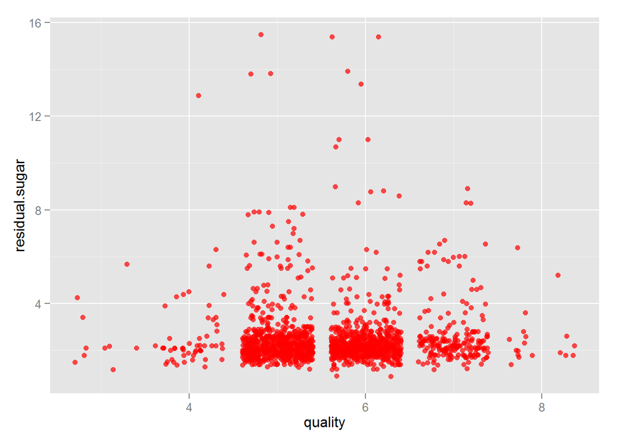

Nearly all wines with the higher sugar ammounts are quality 5, 6 or 7. It’s easy to get tricked here, but notice that most wines in total are also 5,6 or 7. There’s a qualty 4 wine with a really high ammount of sugar as welll, and it’s not easy to conclude whether what we’re seeing is some sort of correlation, or simply the fact that there are so many more wines with quality 5 or 6.

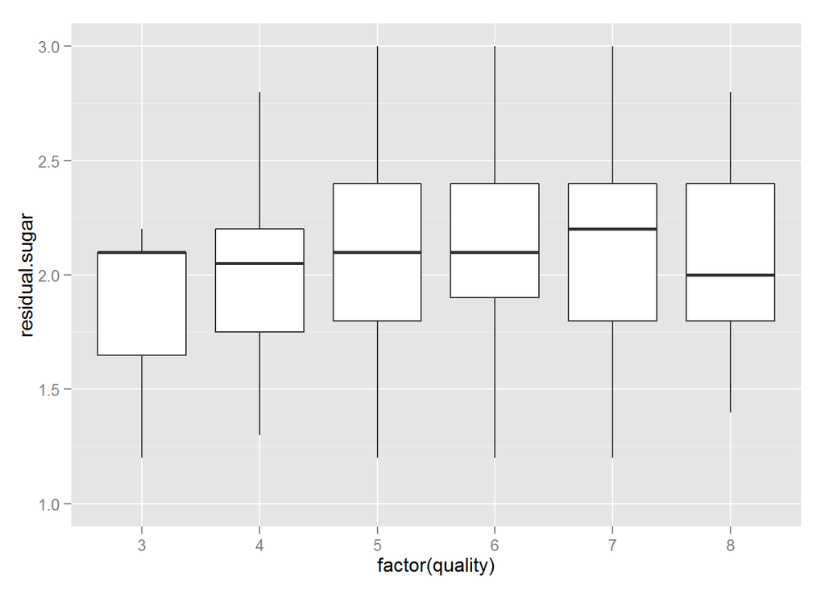

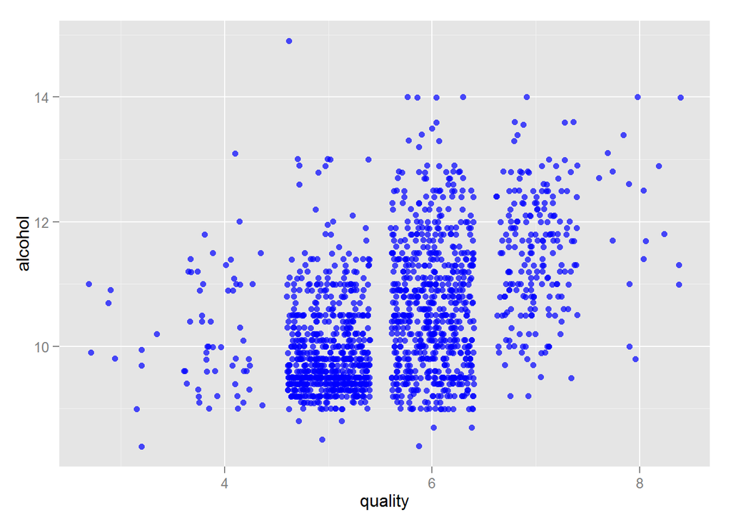

In this plot, we see more of a trend. It looks as if, in general, high quality wines have a bit more alocohol.

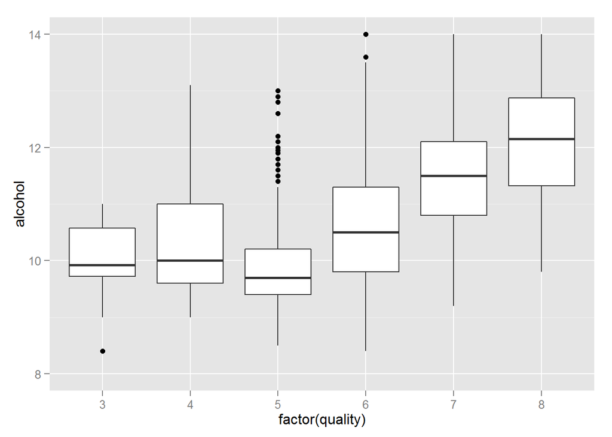

The box plot makes it even more obvious, especially from 5 through 8 there’s a higher ammount of alcohol in the better wines. Let’s look at the correlations both with and without the lower quality wines.

```
##           alcohol   quality
## alcohol 1.0000000 0.4761663
## quality 0.4761663 1.0000000
```

```
##           alcohol   quality
## alcohol 1.0000000 0.5218858
## quality 0.5218858 1.0000000
```

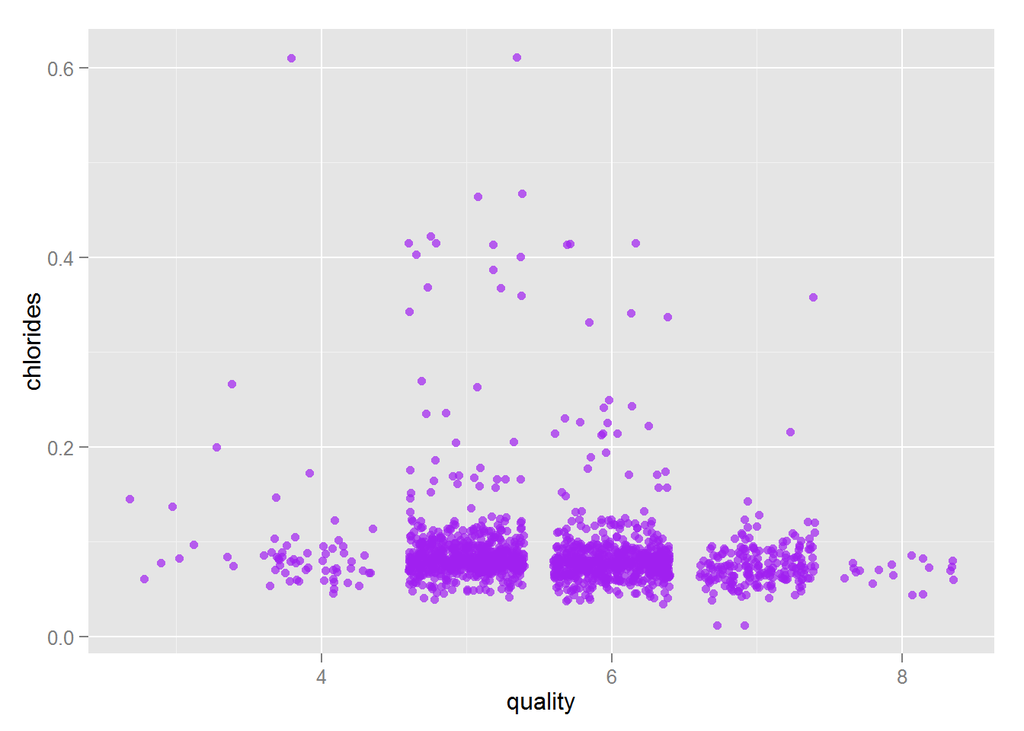

It’s the same thing with this plot as with the sugar one, the differences we observe are possibly just due to a higher number of quality 5 and 6 wines.

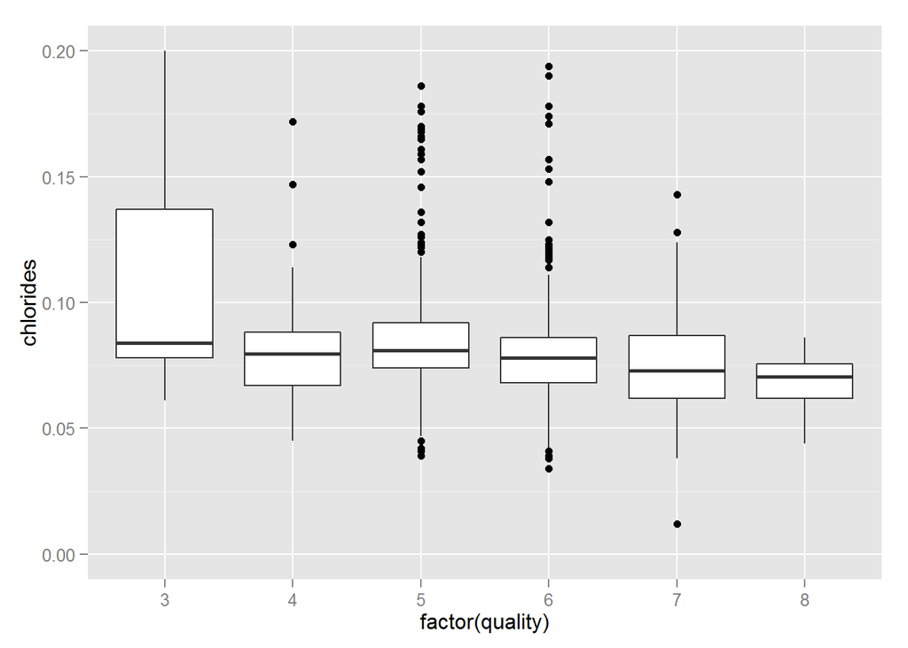

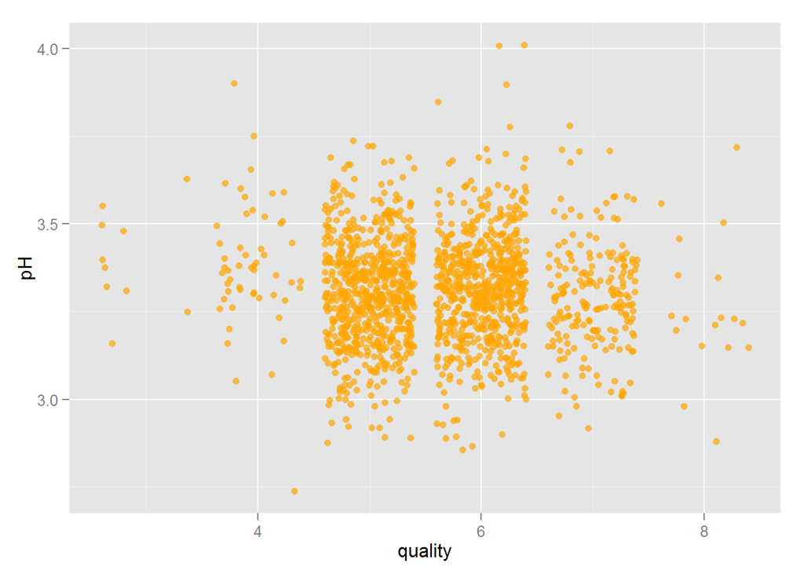

This has a different distribution than the others, and if we scroll back up to look at the histogram for pH, we see that it’s normally distributed in contrary to the first three variables we’ve just looked at which are all heavy sided on the left.

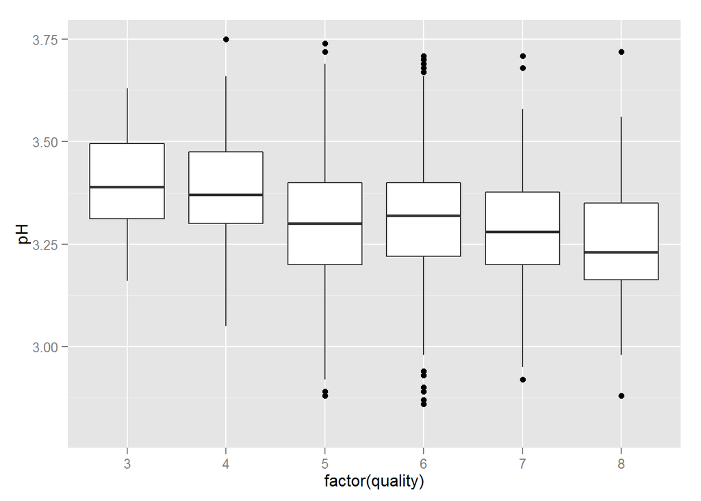

Looking at the boxplot, there seems to be a trend towards higher quality meaning also lower pH. However, the correlation factor between the two is only -0.0577.

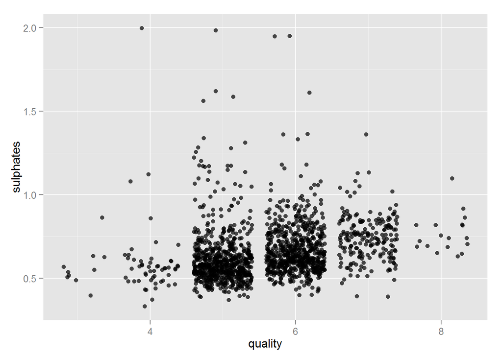

We see some sort of linear trend again, for example not a single one of the really good wines have a low ammount of sulphates.

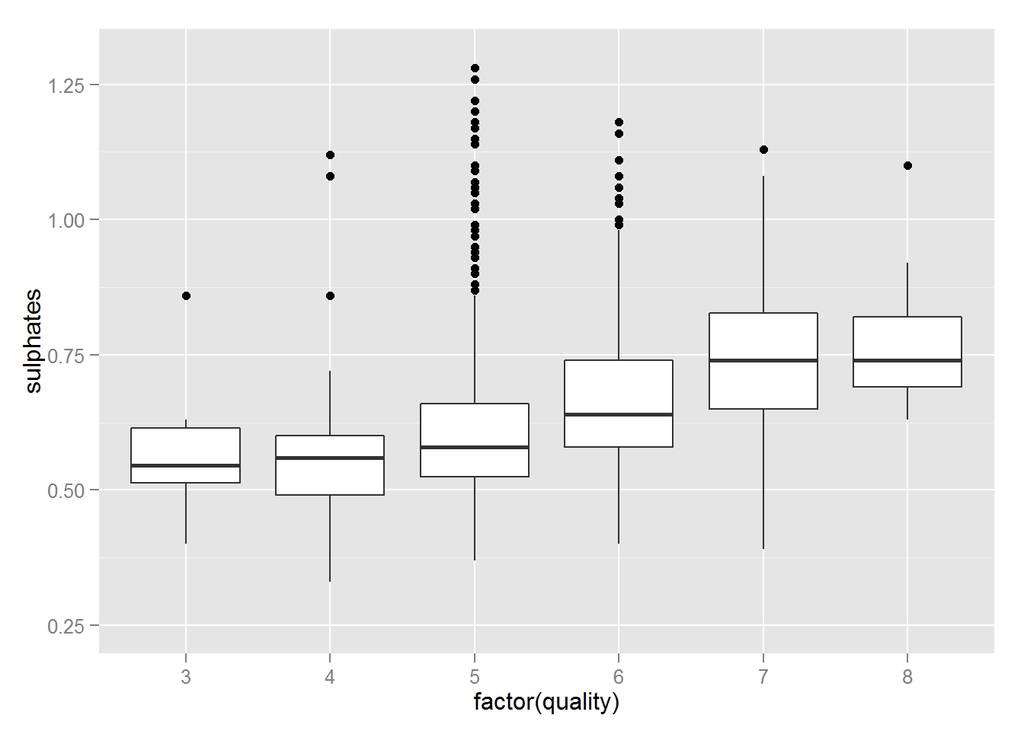

The boxplot tells the same story!

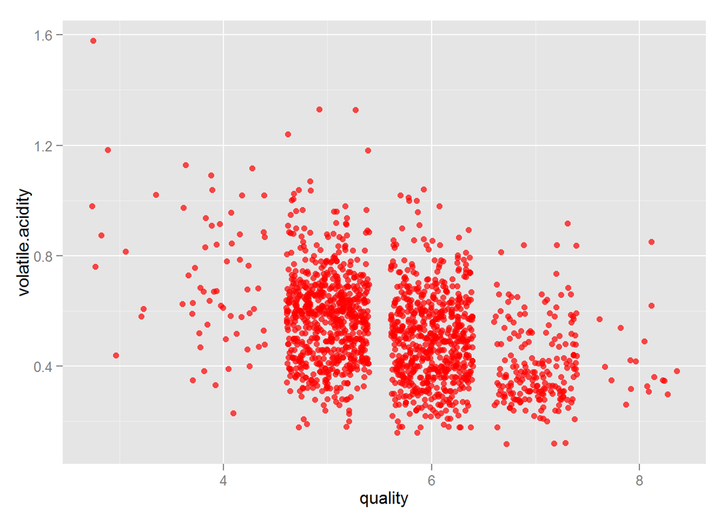

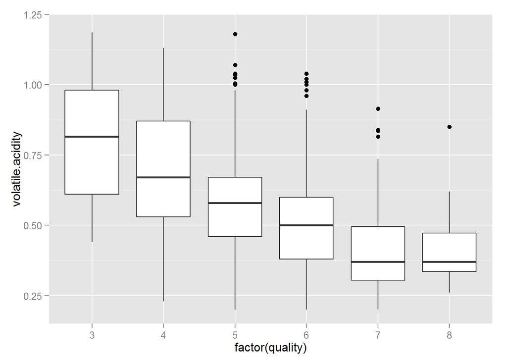

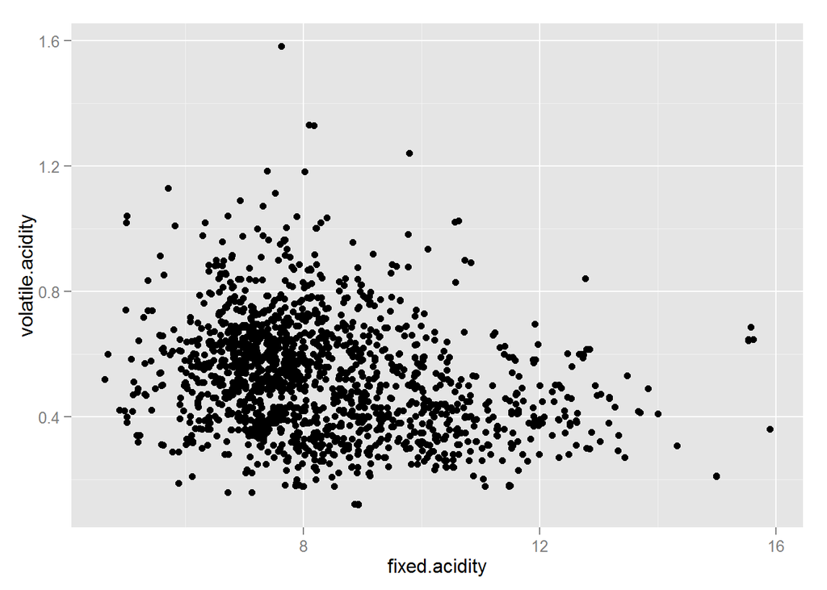

Here we see that the wines with the highest ammount of fixed acidity in general don’t have as high ammount of volatile acidity as the rest of the wines. However, we also have a bigger span in the quantiles here.

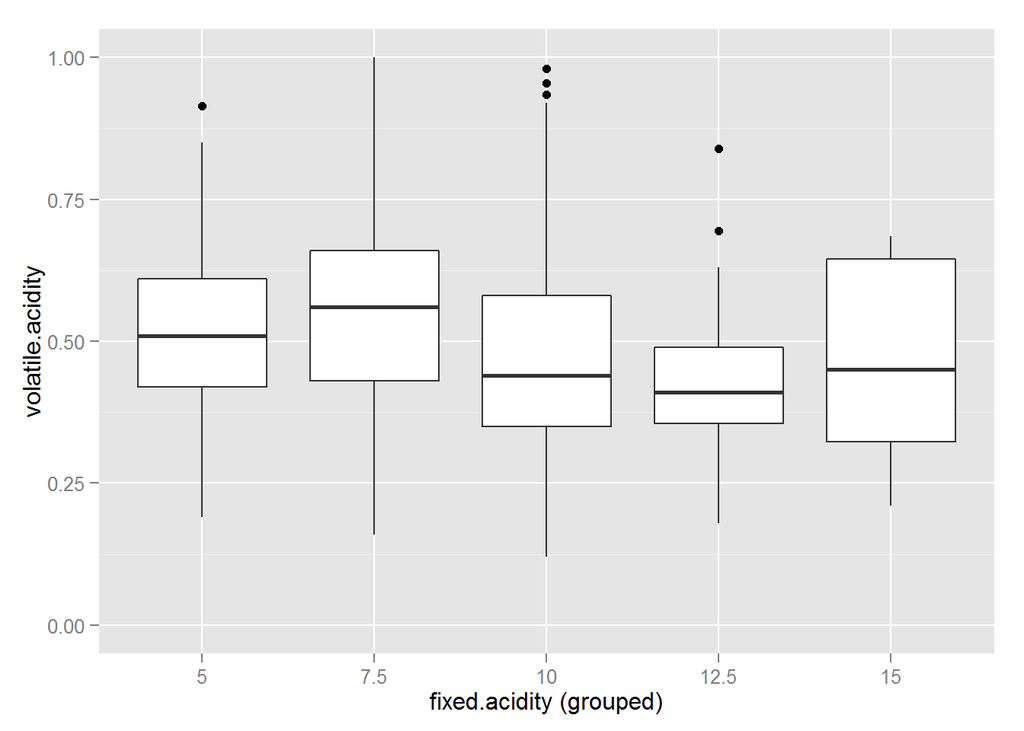

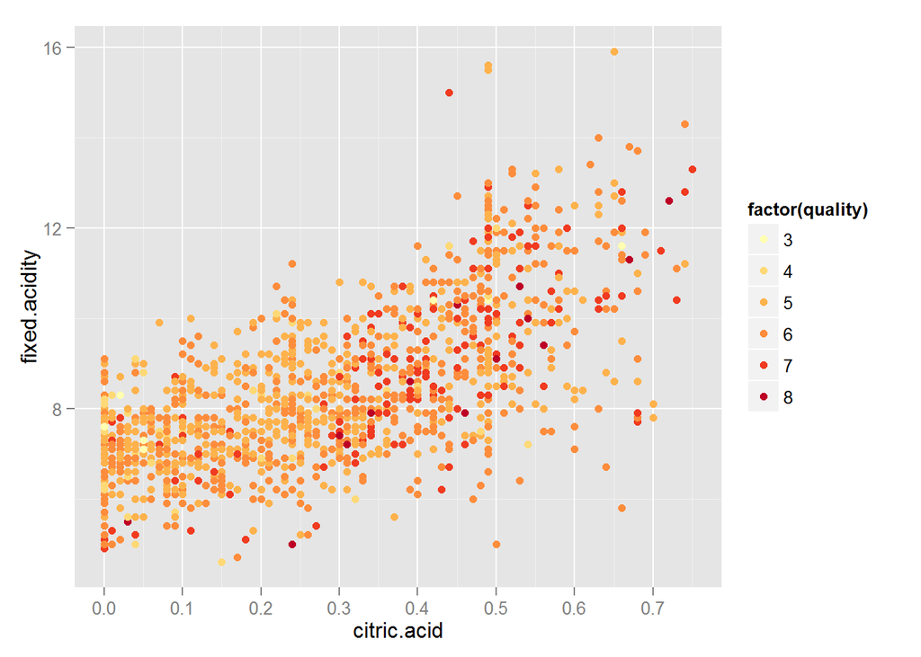

This trend is clearer: there’s some relationship between fixed and citric acid. It could be approximately linear, or one could use a polynomial or exponential function.

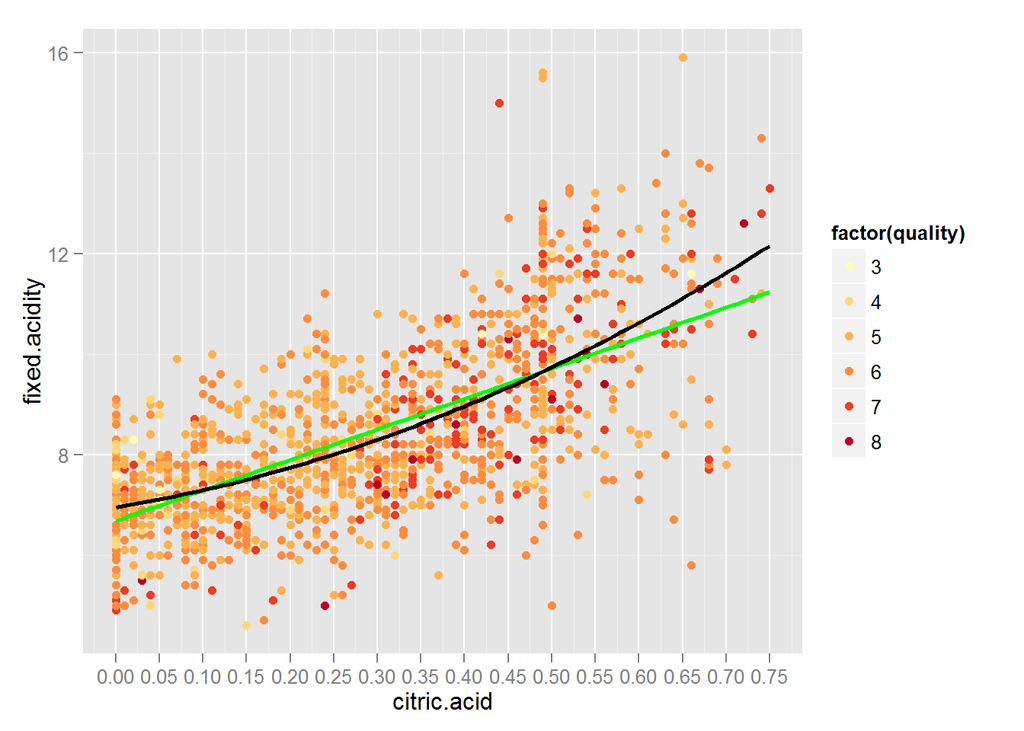

Here’s a look at a linear (green) and a quadratic (black) trendline.

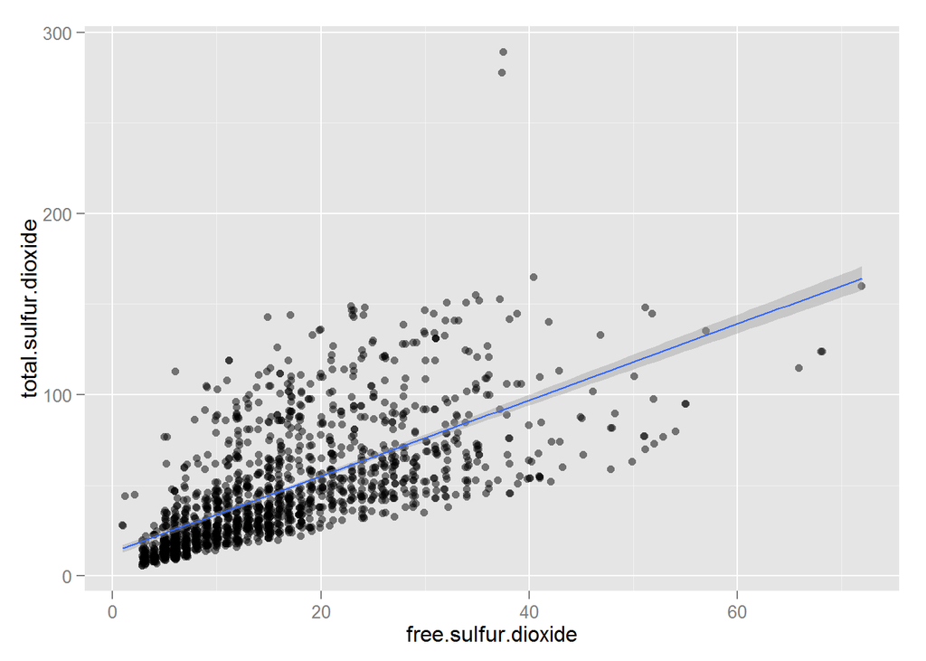

Again there’s a clear trend, but this is rather obvious since the two axes are total and free sulfur dioxide. Total sulfur dioxide consists of the free plus the bound sulfur, and so naturally there’s a relationship between the two, most likely displaying some sort of linearity plus noise.

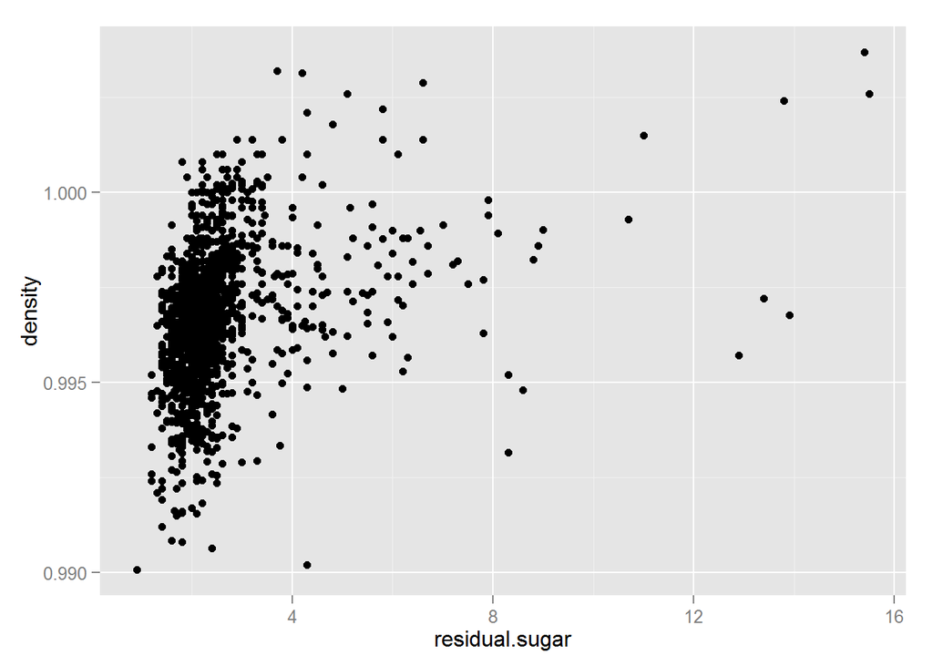

Something seems to be going on here, but the outliers of sugar are messing things up. Let’s remove them!

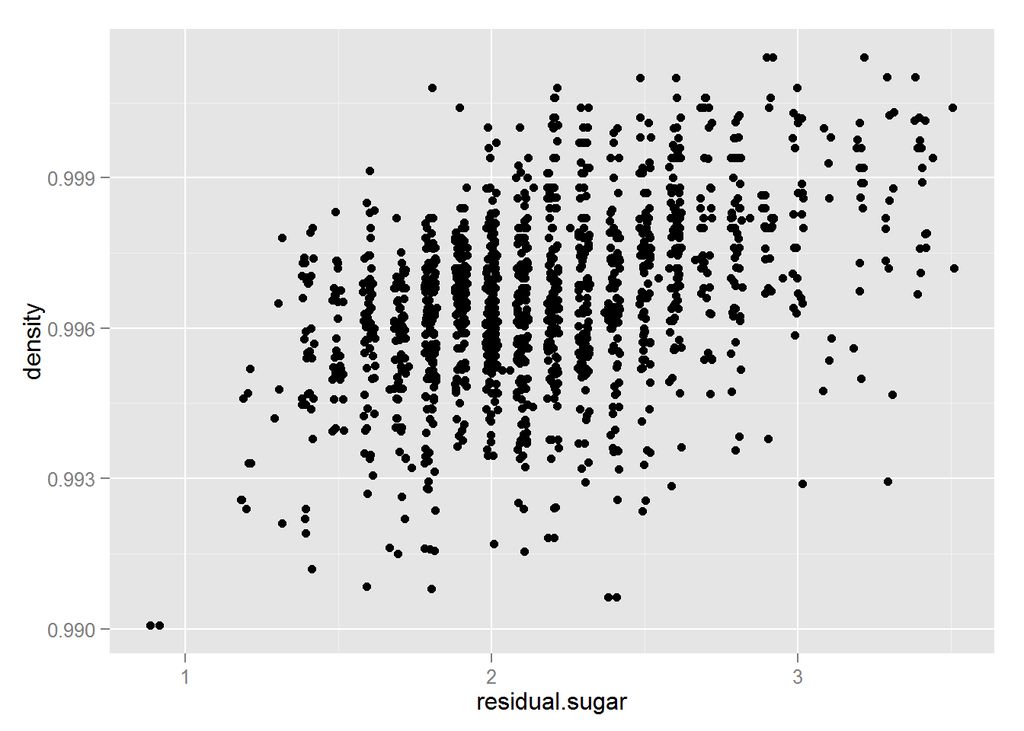

Let’s look at the correlations. Here’s what it used to be:

```
##                residual.sugar    density     quality
## residual.sugar     1.00000000  0.3552834  0.01373164
## density            0.35528337  1.0000000 -0.17491923
## quality            0.01373164 -0.1749192  1.00000000
```

And here’s the 90% with the lowest sugar levels:

```
##                residual.sugar    density    quality
## residual.sugar      1.0000000  0.4235468  0.0184496
## density             0.4235468  1.0000000 -0.2137236
## quality             0.0184496 -0.2137236  1.0000000
```

We see the correlation between sugar and density increase from 0.355 to 0.423, which is quite significant. Also notice correlations going (slightly) up for quality and both density and residual sugar. This could indicate that the outliers in terms of sugar aren’t following the same rules as other wines.